# NUM_Tema5NelinearneRovniceUlohyHlasovanie

**Autor:** Andrej Gajdoš  
*[Ústav matematických vied](https://www.upjs.sk/prirodovedecka-fakulta/ustav/umv/), [Prírodovedecká fakulta](https://www.upjs.sk/prirodovedecka-fakulta/), Univerzita Pavla Jozefa Šafárika v Košiciach,*  
email: andrej.gajdos@upjs.sk

*Tento materiál vznikol za podpory grantu VVGS-2022-2412.*

**NUM: Téma 5 - Numerické riešenie nelineárnych rovníc: úlohy formou hlasovania**

**1. Rovnica $\mathrm{tan}(x)=x$ má:**

A) Nula koreňov;

B) Jeden koreň;

C) Dva korene;

D) Päť koreňov;

E) Nekonečne veľa koreňov.

**2. Polynóm stupňa $n$ má:**

A) $n-1$ koreňov;

B) $n$ koreňov;

C) $n+1$ koreňov;

D) $n+2$ koreňov.

**3. Ak pre spojitú funkciu $f$ platí $f(a)f(b)<0$, potom rovnica $f(x)=0$ má v intervale $\langle a,b \rangle$:**

A) Práve jeden koreň;

B) Nedá sa určiť počet koreňov;

C) Žiaden koreň;

D) Aspoň jeden koreň.

**4. Rovnica $x^2=0$ má koreň v bode $x=0$. Metódu bisekcie nie je možné aplikovať na nájdenie tohto koreňa z dôvodu:**

A) $x^2$ je polynóm;

B) Koreň $x=0$ je dvojnásobný;

C) $x^2$ je vždy nezáporné;

D) Sklon paraboly v bode $x=0$ je nulový.

**5. Aj keď vzťahy pre výpočet odhadu koreňa môžu pri metóde regula-falsi a sečnicovej metóde vyzerať v podstate identicky, rozdiel je v tom, že:**

A) Metóda regula falsi nemá garantovanú konvergenciu;

B) Sečnicová metóda nemá garantovanú konvergenciu;

C) Sečnicová metóda vyžaduje, aby dva počiatočné odhady mali rôzne znamienka;

D) Metóda regula-falsi vyžaduje, aby dva počiatočné odhady mali rôzne znamienka.

**6. Koreň rovnice $(x-4)^2(x+2)$ bol nájdený metódou regula-falsi s počiatočnými odhadmi $x_L=-2.5$, $x_U=-1.0$ a s požadovanou relatívnou chybou nie väčšou ako $10^{-6}$ %. Metóda dokonvergovala ku koreňu $x_r=-1.9999997$ a odpovedajúca absolútna relatívna chyba bola odhadnutá na $8.76110979\times10^{-5}$ %. Na základe uvedených informácií je počet platných číslic nájdeného koreňa, ktorým je možné dôverovať, aspoň:**

A) 3;

B) 4;

C) 5;

D) 6.

**7. Metóda regula-falsi môže mať problém nájsť koreň rovnice $f(x)=x^2-7.4x+13.69=0$ lebo:**

A) $f(x)$ je kvadratická polynomická funkcia;

B) $f'(x)$ je priamka;

C) Nie je možné nájsť dva počiatočné odhady s rôznymi znamienkami; - správne

D) Rovnica má dva identické korene.

**8. Formula pre nájdenie druhej odmocniny z čísla $R$ t.j. riešenie rovnice $x^2-R=0$ pomocou Newtonovej-Raphsonovej metódy má tvar:**

A) $x_{i+1}=\dfrac{x_i}{2}$;

B) $x_{i+1}=\dfrac{3x_i}{2}$;

C) $x_{i+1}=\dfrac{1}{2}\left(x_i+\dfrac{R}{x_i}\right)$;

D) $x_{i+1}=\dfrac{1}{2}\left(3x_i-\dfrac{R}{x_i}\right)$.

**9. Pri hľadaní približnej hodnoty koreňa rovnice $\sin(x)=0$ metódou sečníc by neboli vhodne zvolené počiatočné odhady:**

A) $\dfrac{\pi}{4}$ a $\dfrac{\pi}{2}$;

B) $\dfrac{\pi}{4}$ a $\dfrac{3\pi}{4}$;

C) $-\dfrac{\pi}{2}$ a $\dfrac{\pi}{2}$;

D) $\dfrac{\pi}{3}$ a $\dfrac{\pi}{2}$.

**10. Nech funkcia $f(x)$ má na intervale $\langle a,b \rangle$ koreň. Aby bolo zaručené, že tento koreň je jediný, stačí aby:**

A) Funkcia $f(x)$ bola na tomto intervale konkávna;

B) Funkcia $f(x)$ bola na tomto intervale konvexná;

C) Funkcia $f(x)$ mala prvú deriváciu rovnú nule;

D) Funkcia $f(x)$ bola na tomto intervale rýdzo monotónna.

**11. Je potrebné nájsť najväčší záporný koreň rovnice $f(x)=0$ pomocou Newtonovej metódy. Potom:**

A) Volíme ľubovoľný štartovací bod kdekoľvek na osi $x$;

B) Volíme jeden štartovací bod v blízkosti hľadaného koreňa;

C) Volíme dva štartovacie body tak, aby hľadaný koreň ležal medzi nimi;

D) Volíme dva štartovacie body tak, aby hľadaný koreň ležal medzi nimi a aby funkčné hodnoty v týchto bodoch mali opačné znamienka.

**12. Vyberte, o ktorú iteračnú metódu sa jedná: Graf funkcie $f(x)$ sa na intervale $\langle a,b \rangle$ nahradí priamkou, ktorá prechádza bodmi $[a,f(a)]$, $[b,f(b)]$, pričom priesečník $x_0$ tejto priamky s osou $x$ je približný odhad koreňa. Ďalej sa vyberie ten z intervalov $\langle a,x_0 \rangle $, $\langle x_0,b \rangle$, pre ktorý platí $f(a)f(x_0)<0$ alebo $f(x_0)f(b)<0$ a postup sa opakuje.**

A) Metóda bisekcie;

B) Metóda regula-falsi (metóda tetív);

C) Newtonova metóda (metóda dotyčníc);

D) Metóda sečníc.

**13. V prípade, že postupnosť čísel $x_0,x_1,\ldots$ veľmi pomaly konverguje ku koreňu $x^*$ rovnice $f(x)=0$, tak:**

A) Zastavovaciu podmienku zvolíme radšej nastavením maximálneho počtu iterácií;

B) Zastavovaciu podmienku volíme v tvare $|x_n-x_{n-1}|<\varepsilon$;

C) Zastavovaciu podmienku volíme v tvare $\dfrac{|x_n-x_{n-1}|}{|x_n|}<\varepsilon$.

**14. Ak sú splnené podmienky pre konvergenciu metódy prostej iterácie $x_{n+1}=g(x_n)$ na intervale $\langle a,b \rangle$, tak počet iterácií nutných k dosiahnutiu predpísanej presnosti**

A) je ovplyvnený znamienkom funkčnej hodnoty v počiatočnej aproximácii;

B) je ovplyvnený voľbou počiatočnej aproximácie;

C) nie je ovplyvnený vlastnosťami funkcie $g(x)$;

D) je možné ovplyvniť tým, že funkciu derivujeme a hľadáme korene rovnice $g'(x)=0$.

**15. Keď separujeme korene, tak:**

A) Stanovíme ich presnú hodnotu pomocou niektorej z iteračných metód;

B) Určíme intervaly, ktoré sú dostatočne malé a obsahujú jediný koreň;

C) Nájdeme postupnosť čísel $x_0,x_1,\ldots$, ktorá konverguje ku koreňu;

D) Z grafu približne odhadneme ich hodnotu.

**16. Ktorá z metód využíva pri hľadaní koreňov rovnice $f(x)=0$ ekvivalentný zápis $x=g(x)$ ?**

A) Metóda bisekcie;

B) Newtonova metóda;

C) Metóda prostej iterácie;

D) Metóda sečníc.

**17. Predpokladajme, že dáta uvedené v tabuľke pochádzajú zo spojitej funkcie. Vyberte dvojicu bodov, medzi ktorými musí ležať aspoň jeden koreň takej funkcie:**

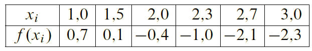

A) $1,0$ a $1,5$;

B) $1,5$ a $2,0$;

C) $2,7$ a $3,0$;

D) $2,3$ a $3,0$.

**18. Ak pri hľadaní nulových bodov funkcie $f(x)$ na intervale $\langle a,b \rangle$ vynecháme predpoklad spojitosti funkcie $f$, tak:**

A) Spojitosť prvej derivácie $f$ zaručuje, že je na intervale $\langle a,b \rangle$ nulový bod;

B) V prípade, že funkcia $f$ je na intervale $\langle a,b \rangle$ monotónna a platí $f(a)f(b)<0$, bude mať funkcia $f$ na intervale $\langle a,b \rangle$ nulový bod;

C) Podmienka $f(a)f(b)<0$ nezaručuje, že na intervale $\langle a,b \rangle$ má funkcia nulový bod;

D) Podmienka $f(a)f(b)<0$ je postačujúca k tomu, aby funkcia $f$ mala na intervale $\langle a,b \rangle$ nulový bod.

**19. Vyberte iteračnú metódu pre hľadanie koreňov nelineárnych rovníc, ktorá potrebuje k odštartovaniu jeden bod v blízkosti koreňa:**

A) Metóda tetiv;

B) Newtonova metóda;

C) Metóda sečníc;

D) Metóda bisekcie.

**20. Ktoré metódy hľadania koreňov nelineárnych rovníc o jednej neznámej je možné rozšíriť na systémy $n$ nelineárnych rovníc s $n$ neznámymi?**

A) Metóda prostej iterácie a Newtonova metóda;

B) Metóda bisekcie a metóda tetív;

C) Metóda prostej iterácie a metóda sečníc;

D) Newtonova metóda a metóda regula-falsi.

**21. Ktoré podmienky zaručujú, že funkcia $f$ má vo vnútri intervalu $\langle a,b \rangle$ koreň?**

A) Funkcia $f$ má v krajných bodoch intervalu hodnoty opačných znamienok;

B) Funkcia $f$ je na tomto intervale spojitá;

C) Funkcia $f$ je na tomto intervale spojitá a hodnoty v krajných bodoch intervalu majú opačné znamienka;

D) Funkcia $f$ je na tomto intervale spojitá a hodnoty v krajných bodoch intervalu majú rovnaké znamienka.

**22. Aproximáciou koreňa rozumieme:**

A) Nájdenie postupnosti čísel $x_0,x_1,\ldots$, ktorá konverguje ku koreňu $x^*$, tzn. platí $\lim\limits_{n\to\infty}x_n=x^*$, $f\left(x^*\right)=0$; - správne

B) Nájdenie intervalov takých, že v každom leží práve jeden koreň;

C) Nájdenie čísel $x^*$, pre ktoré platí $f\left(x^*\right)=0$;

D) Postup, ktorým nájdeme korene danej rovnice.

**23. Ktorá z metód na hľadanie koreňov nelineárnej rovnice $f(x)=0$ vyžaduje existenciu derivácie funkcie $f(x)$ ?**

A) Prostá iteračná metóda;

B) Metóda tetív;

C) Metóda sečníc;

D) Newtonova metóda.

**24. Kedy je zaručené, že Newtonova metóda bude na intervale $\langle a,b \rangle$ konvergovať?**

A) Keď má funkcia $f$ spojitú druhú deriváciu a počiatočná aproximácia $x_0$ je zvolená dostatočné blízko koreňa;

B) Pokiaľ sú splnené podmienky $f(a)f(b)<0$, $f'(x)\neq0$, $f''(x)\neq0$ a za počiatočnú aproximáciu $x_0$ zvolíme $a$ alebo $b$ tak, aby platilo $f(x_0)f''(x_0)>0$;

C) Ak platí $f(a)f(b)>0$ a súčasne $f'(x_0)\neq0$;

D) Newtonova metóda je vždy konvergentná.

**25. Na akom princípe funguje metóda bisekcie?**

A) Nájdeme stred $x_0$ intervalu $\langle a,b \rangle$, zistíme, či je v ňom funkčná hodnota rovná nule, pokiaľ áno, máme koreň. Inak pokračujeme ďalej rovnakým spôsobom s tým, že pracujeme s intervalom, pre ktorý platí $f(a)f(x_0)>0$ resp. $f(b)f(x_0)>0$;

B) Nájdeme stred $x_0$ intervalu $\langle a,b \rangle$, zistíme, či je v ňom funkčná hodnota rovná nule, pokiaľ áno, máme koreň. Inak pokračujeme ďalej rovnakým spôsobom s tým, že pracujeme s intervalom, pre ktorý platí $f(a)f(x_0)<0$ resp. $f(b)f(x_0)<0$;

C) Nájdeme stred $x_0$ intervalu $\langle a,b \rangle$, zistíme, či je v ňom funkčná hodnota rovná nule, pokiaľ áno, máme koreň. Inak pokračujeme ďalej rovnakým spôsobom s tým, že pracujeme s ľubovoľným z intervalov $\langle f(a),f(x_0) \rangle$ resp. $\langle f(x_0),f(b) \rangle$;

D) Ani jedna z predchádzajúcich možností nezodpovedá metóde bisekcie.

**26. Ktorá z iteračných metód pre hľadanie koreňov na intervale $\langle a,b \rangle$ je založená na tzv. *Vete o pevnom bode*?**

A) Prostá iteračná metóda;

B) Dotyčnicová metóda (Newtonova);

C) Metóda sečníc;

D) Metóda tetív (regula-falsi).